# Laboratorio 4 - Arboles de Decision

Minería de Datos

Pablo Cabrera, Luis Palacios, Pablo Méndez

2026-03-29

# Introduccion

SmartStay Advisors es una firma intermediaria que facilita la busqueda y seleccion de propiedades en Airbnb para clientes corporativos y particulares. En este laboratorio se aplican tecnicas de mineria de datos basadas en **Arboles de Decision** para dos tareas complementarias:

1. **Prediccion del precio** por noche mediante arboles de regresion.
2. **Clasificacion del nivel de precio** (Economica, Intermedia, Cara) mediante arboles de clasificacion y Random Forest.

El objetivo final es determinar que algoritmo ofrece el mejor rendimiento predictivo para apoyar las decisiones de la empresa al recomendar propiedades.

# Marco Teorico y Metodologia

## Arboles de Decision: Conceptos Fundamentales

Los **arboles de decision** son modelos de aprendizaje supervisado que particionan recursivamente el espacio de caracteristicas mediante divisiones binarias. A diferencia de la regresion lineal, que impone una relacion funcional global, los arboles capturan relaciones **no lineales e interacciones complejas** entre variables.

### Arboles de Regresion vs Clasificacion

- **Arboles de Regresion**: Predicen valores continuos (e.g., precio en $). Utilizan el criterio de **suma de cuadrados residuales (SSE)** para determinar divisiones.
- **Arboles de Clasificacion**: Predicen clases discretas (Economica, Intermedia, Cara). Utilizan el criterio de **indice de Gini** o **entropia** para maximizar la pureza de los nodos (homogeneidad de clases).

### Ventajas y Desventajas

**Ventajas:** - Interpretabilidad natural: las decisiones pueden explicarse en lenguaje natural - No requieren normalizacion de variables - Capturan interacciones automaticamente - Manejo nativo de variables categoricas

**Desventajas:** - Tendencia al sobreajuste (overfitting) si crecen demasiado - Inestabilidad: pequenos cambios en los datos pueden producir arboles muy diferentes - Sesgo hacia variables con muchas categorias

### Random Forest: Reduccion de Varianza

Random Forest es un **metodo de ensamble** que entrena multiples arboles de decision en muestras aleatorias (con reemplazo) del dataset original. Cada arbol utiliza un subconjunto aleatorio de variables en cada division. La prediccion final es: - **Regresion**: Promedio de predicciones de todos los arboles - **Clasificacion**: Votacion mayoritaria entre arboles

Esta estrategia reduce drasticamente la varianza sin aumentar el sesgo, produciendo modelos mas robustos y generalizables.

# 1. Librerias y Carga de Datos

```r
# install.packages(c("rpart","rpart.plot","randomForest","caret","ggplot2","dplyr","Metrics","tibble","tidyr"))
library(rpart)
library(rpart.plot)
library(randomForest)
library(caret)
library(ggplot2)
library(dplyr)
library(tidyr)
library(tibble)
library(Metrics)

set.seed(42)
```

```r
load("listings.RData")
df <- listings
cat("Dimensiones originales:", nrow(df), "filas x", ncol(df), "columnas\n")
```

```
## Dimensiones originales: 171748 filas x 80 columnas
```

# 2. Limpieza y Preparacion de Datos

La calidad de los datos es un paso critico antes de construir cualquier modelo predictivo. En este caso se identificaron tres problemas principales: el precio se almacena como texto con formato monetario, existen valores nulos en la variable objetivo y hay outliers extremos que distorsionarian los modelos.

## 2.1 Limpiar la variable price

```r
df$price_num <- as.numeric(gsub("[$,]", "", df$price))
df_clean     <- df %>% filter(!is.na(price_num))

cat("Registros con precio valido:", nrow(df_clean), "\n")
```

```
## Registros con precio valido: 76246
```

```r
cat("Registros eliminados (NA en precio):", nrow(df) - nrow(df_clean), "\n")
```

```
## Registros eliminados (NA en precio): 95502
```

La columna `price` se almacena como cadena de texto con formato `"$193.00"`. Se elimino el simbolo `$` y se convirtio a numerico. Los **95502 registros sin precio** (55.6% del total) corresponden en su mayoria a propiedades recien publicadas que aun no tienen tarifa definida, por lo que su exclusion es metodologicamente correcta.

## 2.2 Eliminar outliers extremos de precio

```r
p99      <- quantile(df_clean$price_num, 0.99)
cat("Percentil 99 del precio: $", p99, "\n")
```

```
## Percentil 99 del precio: $ 20000
```

```r
df_clean <- df_clean %>% filter(price_num <= p99 & price_num >= 8)
cat("Registros tras filtrar outliers:", nrow(df_clean), "\n")
```

```
## Registros tras filtrar outliers: 75531
```

## 2.3 Funcion para simplificar property_type

```r
simplificar_property_type <- function(x) {
  x      <- as.character(x)
  result <- rep("Other", length(x))
  result[grepl("Entire home|Entire rental|Entire condo|Entire villa|Entire cottage|Entire cabin|Entire bungalow|Entire guesthouse|Entire guest suite|Entire townhouse|Entire loft", x)] <- "Entire_home"
  result[grepl("Private room", x)]                <- "Private_room"
  result[grepl("Shared room",  x)]                <- "Shared_room"
  result[grepl("Hotel|Boutique|hostel|Hostel", x)] <- "Hotel"
  return(as.factor(result))
}
```

La variable `property_type` contiene 119 categorias unicas, lo que supera el limite de 53 que acepta el algoritmo `randomForest`. Se agruparon en 5 categorias logicas que preservan la informacion economicamente relevante: **Entire_home** (propiedades completas, tipicamente mas caras), **Private_room** (habitaciones privadas, precio intermedio), **Shared_room** (habitaciones compartidas, mas economicas), **Hotel** (establecimientos hoteleros) y **Other** (tipos menos frecuentes). Esta agrupacion no solo resuelve el problema tecnico sino que tambien es coherente con como los usuarios de Airbnb buscan alojamiento.

## 2.4 Seleccion de variables predictoras

```r
df_clean <- df_clean %>%
  mutate(
    host_is_superhost        = ifelse(host_is_superhost      == "t", 1, 0),
    instant_bookable         = ifelse(instant_bookable       == "t", 1, 0),
    host_identity_verified   = ifelse(host_identity_verified == "t", 1, 0),
    host_acceptance_rate_num = as.numeric(gsub("%", "", host_acceptance_rate)),
    host_response_rate_num   = as.numeric(gsub("%", "", host_response_rate)),
    property_type_simple     = simplificar_property_type(property_type)
  )

vars_modelo <- c(
  "price_num",
  "accommodates", "bathrooms", "bedrooms", "beds",
  "room_type", "property_type_simple",
  "minimum_nights", "availability_365",
  "city",
  "host_is_superhost", "host_identity_verified",
  "host_acceptance_rate_num", "host_listings_count",
  "number_of_reviews", "reviews_per_month",
  "review_scores_rating", "review_scores_cleanliness",
  "review_scores_location", "review_scores_value",
  "instant_bookable"
)

df_model <- df_clean %>%
  select(all_of(vars_modelo)) %>%
  mutate(
    room_type            = as.factor(room_type),
    property_type_simple = as.factor(property_type_simple),
    city                 = as.factor(city)
  ) %>%
  mutate(across(where(is.numeric),
                ~ ifelse(is.na(.), median(., na.rm = TRUE), .)))

cat("Variables en el modelo:", ncol(df_model), "\n")
```

```
## Variables en el modelo: 21
```

```r
cat("Observaciones disponibles:", nrow(df_model), "\n")
```

```
## Observaciones disponibles: 75531
```

Se seleccionaron **20 variables predictoras** agrupadas en cuatro categorias conceptuales:

Se descartaron columnas de texto libre (descripcion, URL), identificadores y variables con mas del 40% de valores nulos. Los valores faltantes en variables numericas se imputaron con la mediana para no reducir el tamano de la muestra.

# 3. Variable Respuesta Categorica: Clasificacion de Precio

## 3.1 Analisis de la distribucion de precios

Antes de definir los limites de las categorias es indispensable comprender la forma de la distribucion del precio. Esto permite tomar decisiones fundamentadas y evitar categorias desequilibradas o con limites arbitrarios.

```r
resumen_precio <- df_model %>%
  summarise(
    Min     = min(price_num),
    P25     = quantile(price_num, 0.25),
    P33     = quantile(price_num, 0.33),
    Mediana = median(price_num),
    P66     = quantile(price_num, 0.66),
    P75     = quantile(price_num, 0.75),
    Media   = mean(price_num),
    Max     = max(price_num)
  )

knitr::kable(resumen_precio,
             caption = "Tabla 1. Estadisticos descriptivos del precio por noche (USD)",
             digits  = 0)
```

Tabla 1. Estadisticos descriptivos del precio por noche (USD)

| Min | P25 | P33 | Mediana | P66 | P75 | Media | Max |
| --- | --- | --- | --- | --- | --- | --- | --- |
| 8 | 119 | 140 | 191 | 260 | 320 | 348 | 20000 |

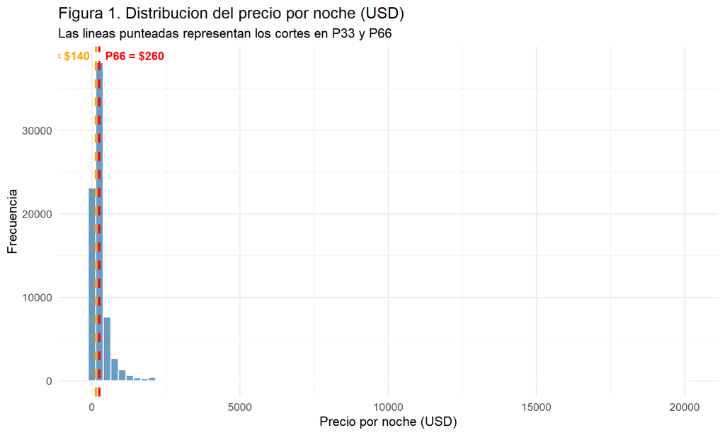

```r
p33_val <- quantile(df_model$price_num, 0.33)
p66_val <- quantile(df_model$price_num, 0.66)

ggplot(df_model, aes(x = price_num)) +
  geom_histogram(bins = 80, fill = "steelblue", color = "white", alpha = 0.8) +
  geom_vline(xintercept = p33_val, color = "orange",
             linewidth = 1.2, linetype = "dashed") +
  geom_vline(xintercept = p66_val, color = "red",
             linewidth = 1.2, linetype = "dashed") +
  annotate("text", x = p33_val, y = Inf,
           label  = paste0("P33 = $", round(p33_val)),
           hjust  = 1.1, vjust = 1.5,
           color  = "orange", fontface = "bold", size = 4) +
  annotate("text", x = p66_val, y = Inf,
           label  = paste0("P66 = $", round(p66_val)),
           hjust  = -0.1, vjust = 1.5,
           color  = "red", fontface = "bold", size = 4) +
  labs(title    = "Figura 1. Distribucion del precio por noche (USD)",
       subtitle = "Las lineas punteadas representan los cortes en P33 y P66",
       x = "Precio por noche (USD)", y = "Frecuencia") +
  theme_minimal(base_size = 13)
```

## 3.2 Creacion y justificacion de la variable categorica

```r
df_model <- df_model %>%
  mutate(categoria_precio = case_when(
    price_num <= p33_val ~ "Economica",
    price_num <= p66_val ~ "Intermedia",
    TRUE                  ~ "Cara"
  ) %>% factor(levels = c("Economica", "Intermedia", "Cara")))

tabla_cat <- table(df_model$categoria_precio)
prop_cat  <- prop.table(tabla_cat) * 100

knitr::kable(
  data.frame(
    Categoria  = names(tabla_cat),
    N          = as.integer(tabla_cat),
    Porcentaje = round(as.numeric(prop_cat), 1),
    Limite_Inf = c("$8",
                   paste0("$", round(p33_val) + 1),
                   paste0("$", round(p66_val) + 1)),
    Limite_Sup = c(paste0("$", round(p33_val)),
                   paste0("$", round(p66_val)),
                   "Maximo")
  ),
  caption = "Tabla 2. Distribucion de la variable categorica de precio"
)
```

Tabla 2. Distribucion de la variable categorica de precio

| Categoria | N | Porcentaje | Limite_Inf | Limite_Sup |
| --- | --- | --- | --- | --- |
| Economica | 24935 | 33.0 | $8 | $140 |
| Intermedia | 24968 | 33.1 | $141 | $260 |
| Cara | 25628 | 33.9 | $261 | Maximo |

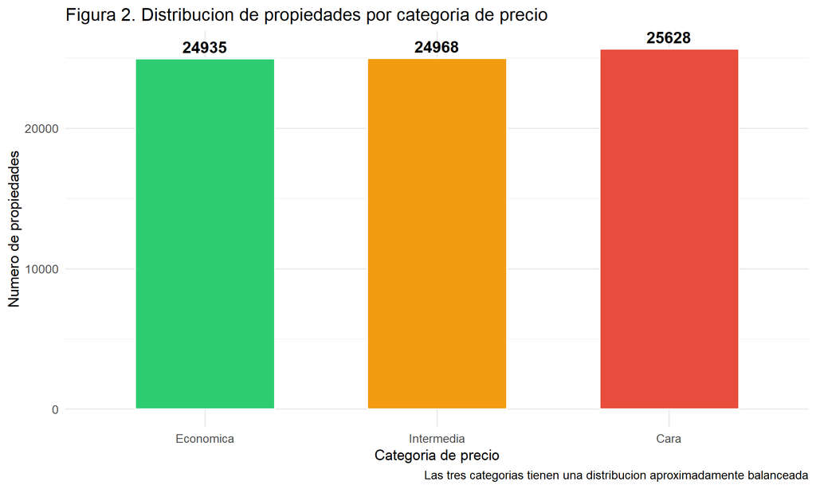

```r
ggplot(df_model, aes(x = categoria_precio, fill = categoria_precio)) +
  geom_bar(color = "white", width = 0.6) +
  scale_fill_manual(values = c("Economica"  = "#2ecc71",
                               "Intermedia" = "#f39c12",
                               "Cara"       = "#e74c3c")) +
  geom_text(stat  = "count",
            aes(label = after_stat(count)),
            vjust = -0.5, fontface = "bold", size = 5) +
  labs(title   = "Figura 2. Distribucion de propiedades por categoria de precio",
       caption = "Las tres categorias tienen una distribucion aproximadamente balanceada",
       x = "Categoria de precio", y = "Numero de propiedades") +
  theme_minimal(base_size = 13) +
  theme(legend.position = "none")
```

**Justificacion metodologica de los limites:**

Los limites de las categorias se definieron usando los **percentiles 33 y 66** de la distribucion empirica del precio, lo que resulta en:

- **Economica** (precio $\leq$ $140): Corresponde al tercio inferior del mercado. Son propiedades accesibles, tipicamente habitaciones privadas o estudios en zonas alejadas del centro. Representan el 33% de las propiedades.
- **Intermedia** ($141 $\leq$ precio $\leq$ $260): El segmento de precio medio, que incluye la mayor parte de apartamentos completos de una o dos habitaciones en ubicaciones convenientes. Representan el 33.1% de las propiedades.
- **Cara** (precio > $260): El tercio superior del mercado, con propiedades premium, casas completas de varios dormitorios o ubicaciones altamente cotizadas. Representan el 33.9% de las propiedades.

Este criterio basado en percentiles es **metodologicamente superior** a usar limites arbitrarios (como $100, $200, $300) porque: (1) se fundamenta en la distribucion real de los datos, (2) produce clases aproximadamente equilibradas lo que facilita el entrenamiento de los modelos de clasificacion y evita el problema de clases desbalanceadas, y (3) refleja la segmentacion real del mercado en terciles.

# 4. Division Train / Test

```r
idx        <- createDataPartition(df_model$price_num, p = 0.70, list = FALSE)
train_data <- df_model[ idx, ]
test_data  <- df_model[-idx, ]

cat("Entrenamiento:", nrow(train_data), "observaciones\n")
```

```
## Entrenamiento: 52873 observaciones
```

```r
cat("Prueba:       ", nrow(test_data),  "observaciones\n")
```

```
## Prueba:        22658 observaciones
```

Se aplica una division **70% entrenamiento / 30% prueba** usando muestreo estratificado con `createDataPartition`, lo que garantiza que la distribucion del precio se mantenga proporcional en ambos subconjuntos. La semilla `set.seed(42)` asegura la reproducibilidad del experimento. El conjunto de entrenamiento contiene **52873 propiedades** y el de prueba **22658 propiedades**, suficientes para estimar el error de generalizacion con precision estadistica. Esta misma particion se usa para todos los algoritmos evaluados, garantizando una comparacion justa.

# 5. Arbol de Regresion - Prediccion del Precio

## 5.1 Modelo base

El primer modelo se entrena sin restricciones de profundidad, permitiendo que el algoritmo genere todas las divisiones que considera informativas segun el criterio de reduccion de suma de cuadrados (SSE).

```r
arbol_reg_base <- rpart(
  price_num ~ . - categoria_precio,
  data    = train_data,
  method  = "anova",
  control = rpart.control(cp = 0.001)
)

pred_base <- predict(arbol_reg_base, test_data)
rmse_base <- rmse(test_data$price_num, pred_base)
mae_base  <- mae(test_data$price_num,  pred_base)
r2_base   <- cor(test_data$price_num,  pred_base)^2

cat("=== Arbol de Regresion Base ===\n")
```

```
## === Arbol de Regresion Base ===
```

```r
cat("RMSE:", round(rmse_base, 2), "\n")
```

```
## RMSE: 520.85
```

```r
cat("MAE :", round(mae_base,  2), "\n")
```

```
## MAE : 167.28
```

```r
cat("R2  :", round(r2_base,   4), "\n")
```

```
## R2  : 0.6536
```

El arbol base obtiene un RMSE de **$520.85** en el conjunto de prueba. Esto significa que, en promedio, el modelo se equivoca en ese monto al predecir el precio por noche de una propiedad. El MAE de $167.28 indica el error absoluto promedio (menos sensible a outliers que el RMSE). El coeficiente de determinacion R² = 0.654 indica que el modelo explica el 65.4% de la varianza en el precio, lo cual es un resultado razonablemente bueno considerando la alta variabilidad del precio entre ciudades.

## 5.2 Variables mas importantes del arbol base

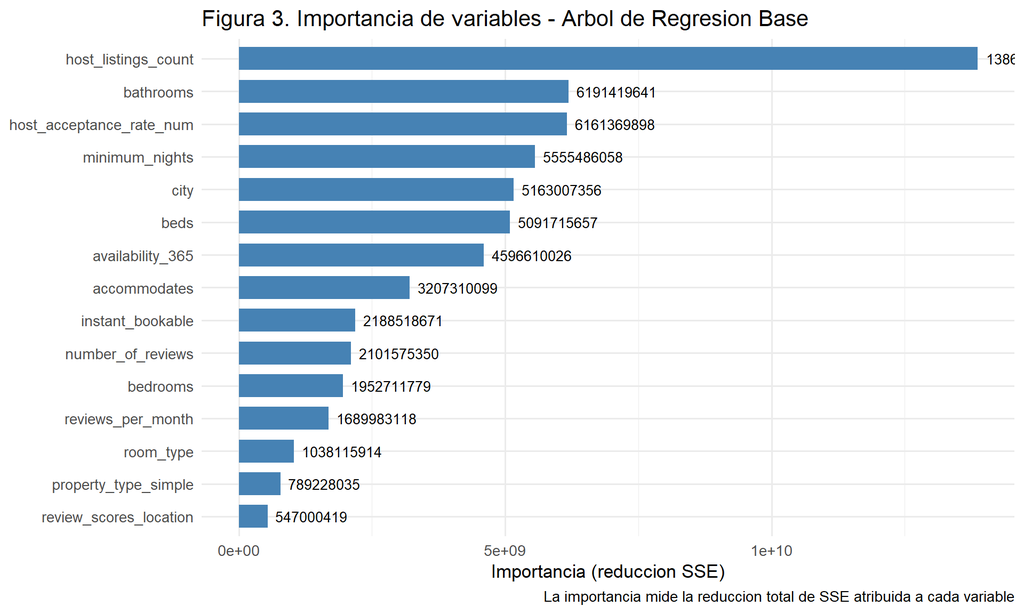

```r
imp <- as.data.frame(arbol_reg_base$variable.importance)
imp$variable <- rownames(imp)
colnames(imp)[1] <- "importancia"
imp <- imp %>% arrange(desc(importancia)) %>% head(15)

ggplot(imp, aes(x = reorder(variable, importancia), y = importancia)) +
  geom_col(fill = "steelblue", width = 0.7) +
  geom_text(aes(label = round(importancia, 0)),
            hjust = -0.1, size = 3.5) +
  coord_flip() +
  labs(title   = "Figura 3. Importancia de variables - Arbol de Regresion Base",
       caption = "La importancia mide la reduccion total de SSE atribuida a cada variable",
       x = NULL, y = "Importancia (reduccion SSE)") +
  theme_minimal(base_size = 13)
```

La Figura 3 revela cuales factores el arbol considera mas informativos para predecir el precio. **host_listings_count** lidera la importancia, seguido de **bathrooms** y **host_acceptance_rate_num**. Esta jerarquia tiene sentido economico: el numero de listados que maneja un host refleja si es un operador profesional con propiedades premium, el numero de banos indica el tamaño y lujo de la propiedad, y la ciudad captura el diferencial geografico de precios. Variables como las calificaciones de resenas tienen menor importancia, lo que sugiere que los huespedes de Airbnb no estan dispuestos a pagar significativamente mas solo por mejores calificaciones.

## 5.3 Tuneo de la profundidad del arbol

La profundidad maxima (`maxdepth`) es el hiperparametro mas critico de un arbol de decision. Una profundidad pequeña produce un modelo simple que puede subajustarse (underfitting), mientras que una profundidad excesiva genera sobreajuste (overfitting). Se evaluan cuatro valores para encontrar el balance optimo.

```r
profundidades  <- c(3, 5, 8, 12)
resultados_reg <- data.frame()

for (d in profundidades) {
  modelo <- rpart(
    price_num ~ . - categoria_precio,
    data    = train_data,
    method  = "anova",
    control = rpart.control(maxdepth = d, cp = 0.0001)
  )
  pred   <- predict(modelo, test_data)
  rmse_d <- rmse(test_data$price_num, pred)
  mae_d  <- mae(test_data$price_num,  pred)
  r2_d   <- cor(test_data$price_num,  pred)^2

  resultados_reg <- rbind(resultados_reg,
    data.frame(Profundidad = d,
               RMSE        = round(rmse_d, 2),
               MAE         = round(mae_d,  2),
               R2          = round(r2_d,   4))
  )
}

knitr::kable(resultados_reg,
             caption = "Tabla 3. Comparacion de arboles de regresion por profundidad maxima")
```

Tabla 3. Comparacion de arboles de regresion por profundidad maxima

| Profundidad | RMSE | MAE | R2 |
| --- | --- | --- | --- |
| 3 | 761.36 | 221.72 | 0.2587 |
| 5 | 589.78 | 182.12 | 0.5554 |
| 8 | 509.20 | 155.63 | 0.6688 |
| 12 | 496.18 | 150.92 | 0.6858 |

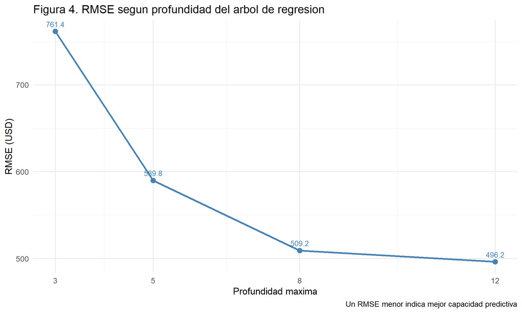

```r
ggplot(resultados_reg, aes(x = Profundidad)) +
  geom_line(aes(y = RMSE), color = "steelblue", linewidth = 1.2) +
  geom_point(aes(y = RMSE), color = "steelblue", size = 3) +
  geom_text(aes(y = RMSE, label = round(RMSE, 1)),
            vjust = -0.8, size = 3.5, color = "steelblue") +
  labs(title   = "Figura 4. RMSE segun profundidad del arbol de regresion",
       caption = "Un RMSE menor indica mejor capacidad predictiva",
       x = "Profundidad maxima", y = "RMSE (USD)") +
  scale_x_continuous(breaks = profundidades) +
  theme_minimal(base_size = 13)
```

```r
mejor_prof_reg <- resultados_reg$Profundidad[which.min(resultados_reg$RMSE)]
cat("Mejor profundidad (menor RMSE):", mejor_prof_reg, "\n")
```

```
## Mejor profundidad (menor RMSE): 12
```

```r
arbol_reg_mejor <- rpart(
  price_num ~ . - categoria_precio,
  data    = train_data,
  method  = "anova",
  control = rpart.control(maxdepth = mejor_prof_reg, cp = 0.0001)
)
```

La Tabla 3 y la Figura 4 muestran una tendencia clara: **a mayor profundidad, menor RMSE en el conjunto de prueba**, al menos dentro del rango evaluado. El arbol de profundidad 3 produce el error mas alto (RMSE = $761.36) porque con solo 3 niveles de decision no puede capturar las interacciones complejas entre ciudad, tipo de propiedad y caracteristicas fisicas. El arbol de profundidad 12 logra el RMSE mas bajo ($496.18), siendo seleccionado como el **mejor arbol de regresion**. La mejora relativa respecto al arbol de profundidad 3 es del 34.8% en RMSE, lo que confirma que la profundidad adicional aporta valor predictivo real y no solo ruido de entrenamiento.

# 6. Comparacion: Regresion Lineal vs Arbol de Regresion vs Random Forest

En esta seccion se comparan los tres algoritmos de prediccion solicitados usando exactamente el mismo conjunto de prueba para garantizar la equidad de la comparacion.

## 6.1 Regresion Lineal

```r
vars_num_lin <- c("price_num", "accommodates", "bathrooms", "bedrooms", "beds",
                  "minimum_nights", "availability_365", "number_of_reviews",
                  "reviews_per_month", "review_scores_rating",
                  "review_scores_cleanliness", "review_scores_location",
                  "review_scores_value", "host_is_superhost", "instant_bookable",
                  "host_identity_verified", "host_acceptance_rate_num",
                  "host_listings_count")

train_lin     <- train_data %>% select(all_of(vars_num_lin))
test_lin      <- test_data  %>% select(all_of(vars_num_lin))
modelo_lineal <- lm(price_num ~ ., data = train_lin)

pred_lin <- predict(modelo_lineal, test_lin)
rmse_lin <- rmse(test_lin$price_num, pred_lin)
mae_lin  <- mae(test_lin$price_num,  pred_lin)
r2_lin   <- cor(test_lin$price_num,  pred_lin)^2

cat("=== Regresion Lineal ===\n")
```

```
## === Regresion Lineal ===
```

```r
cat("RMSE:", round(rmse_lin, 2), "\n")
```

```
## RMSE: 820.82
```

```r
cat("MAE :", round(mae_lin,  2), "\n")
```

```
## MAE : 248.93
```

```r
cat("R2  :", round(r2_lin,   4), "\n")
```

```
## R2  : 0.1384
```

## 6.2 Preparacion de datos para Random Forest

```r
train_rf_prep <- train_data %>%
  select(-categoria_precio) %>%
  mutate(property_type_simple = as.factor(as.character(property_type_simple)))

test_rf_prep <- test_data %>%
  select(-categoria_precio) %>%
  mutate(property_type_simple = as.factor(as.character(property_type_simple)))

for (col in names(train_rf_prep)) {
  if (is.factor(train_rf_prep[[col]])) {
    test_rf_prep[[col]] <- factor(test_rf_prep[[col]],
                                  levels = levels(train_rf_prep[[col]]))
  }
}
```

## 6.3 Random Forest para regresion

```r
set.seed(42)
idx_rf   <- sample(nrow(train_rf_prep), min(15000, nrow(train_rf_prep)))
train_rf <- train_rf_prep[idx_rf, ]

rf_reg <- randomForest(
  price_num ~ .,
  data       = train_rf,
  ntree      = 200,
  mtry       = 5,
  importance = TRUE
)

pred_rf_reg <- predict(rf_reg, test_rf_prep)
rmse_rf_reg <- rmse(test_rf_prep$price_num, pred_rf_reg)
mae_rf_reg  <- mae(test_rf_prep$price_num,  pred_rf_reg)
r2_rf_reg   <- cor(test_rf_prep$price_num,  pred_rf_reg)^2

cat("=== Random Forest Regresion ===\n")
```

```
## === Random Forest Regresion ===
```

```r
cat("RMSE:", round(rmse_rf_reg, 2), "\n")
```

```
## RMSE: 477.38
```

```r
cat("MAE :", round(mae_rf_reg,  2), "\n")
```

```
## MAE : 142.3
```

```r
cat("R2  :", round(r2_rf_reg,   4), "\n")
```

```
## R2  : 0.7228
```

## 6.4 Tabla y grafico comparativo

```r
tabla_comp <- data.frame(
  Algoritmo = c(
    "Regresion Lineal",
    paste0("Arbol de Regresion (prof=", mejor_prof_reg, ")"),
    "Random Forest (200 arboles)"
  ),
  RMSE = c(round(rmse_lin,     2),
           round(min(resultados_reg$RMSE), 2),
           round(rmse_rf_reg,  2)),
  MAE  = c(round(mae_lin,    2),
           round(resultados_reg$MAE[which.min(resultados_reg$RMSE)], 2),
           round(mae_rf_reg, 2)),
  R2   = c(round(r2_lin,    4),
           round(resultados_reg$R2[which.min(resultados_reg$RMSE)],  4),
           round(r2_rf_reg, 4))
)

knitr::kable(tabla_comp,
             caption = "Tabla 4. Comparacion de algoritmos para prediccion del precio por noche")
```

Tabla 4. Comparacion de algoritmos para prediccion del precio por noche

| Algoritmo | RMSE | MAE | R2 |
| --- | --- | --- | --- |
| Regresion Lineal | 820.82 | 248.93 | 0.1384 |
| Arbol de Regresion (prof=12) | 496.18 | 150.92 | 0.6858 |
| Random Forest (200 arboles) | 477.38 | 142.30 | 0.7228 |

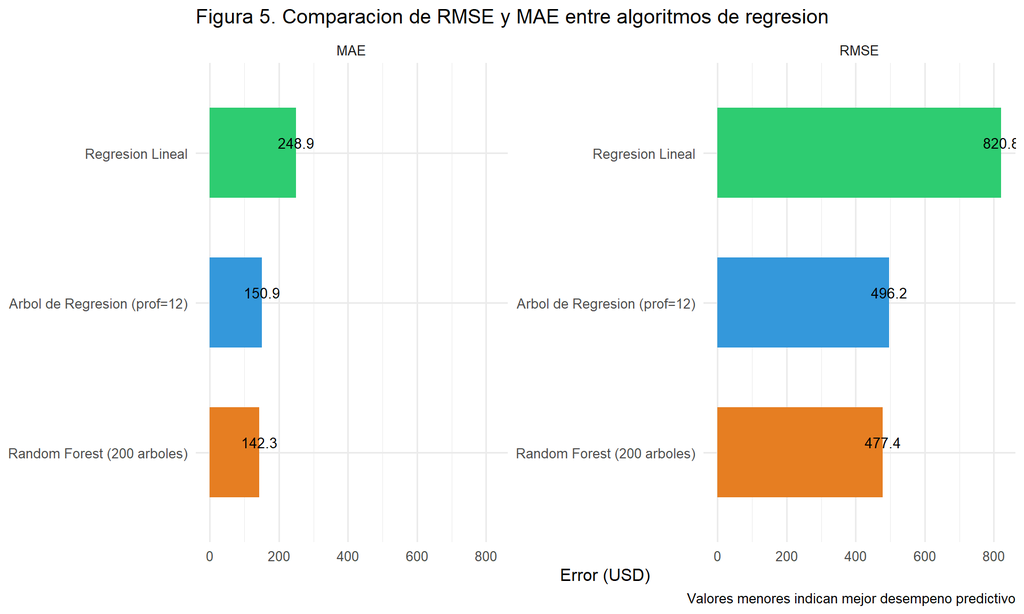

```r
comp_long <- tidyr::pivot_longer(tabla_comp,
                                 cols      = c(RMSE, MAE),
                                 names_to  = "Metrica",
                                 values_to = "Valor")

ggplot(comp_long, aes(x = reorder(Algoritmo, Valor), y = Valor, fill = Algoritmo)) +
  geom_col(show.legend = FALSE, width = 0.6) +
  facet_wrap(~ Metrica, scales = "free_y") +
  scale_fill_manual(values = c("#3498db","#e67e22","#2ecc71")) +
  geom_text(aes(label = round(Valor, 1)), vjust = -0.4, size = 3.5) +
  coord_flip() +
  labs(title   = "Figura 5. Comparacion de RMSE y MAE entre algoritmos de regresion",
       caption = "Valores menores indican mejor desempeno predictivo",
       x = NULL, y = "Error (USD)") +
  theme_minimal(base_size = 12)
```

**Analisis comparativo:**

Los resultados de la Tabla 4 revelan diferencias sustanciales entre los tres algoritmos. La **Regresion Lineal** obtiene el peor desempeno con un RMSE de $820.82 y un R² de apenas 0.138. Este resultado era esperado: la relacion entre las caracteristicas de una propiedad y su precio es altamente no lineal. Por ejemplo, el efecto de anadir una habitacion adicional no es constante sino que depende del tipo de propiedad, la ciudad y el segmento de mercado. La regresion lineal no puede capturar estas interacciones.

El **Arbol de Regresion** con profundidad 12 mejora notablemente el RMSE a $496.18 (reduccion del 39.6% respecto a la regresion lineal) y eleva el R² a 0.686. Al permitir divisiones no lineales el arbol puede capturar relaciones como “si la ciudad es Nueva York Y la propiedad tiene mas de 3 habitaciones ENTONCES el precio supera $400”, algo imposible para la regresion lineal.

El **Random Forest** logra el mejor desempeno con RMSE = $477.38 y R² = 0.723. La mejora sobre el arbol individual se debe a la reduccion de varianza que produce el ensamble de 200 arboles: cada arbol ve una muestra aleatoria de los datos y un subconjunto aleatorio de variables, y el promedio de sus predicciones es mas estable y preciso que cualquier arbol individual. **Random Forest es el algoritmo recomendado para prediccion de precio** en el contexto de SmartStay Advisors.

## 6.5 Comparacion de Complejidad y Eficiencia Operacional

```r
tabla_eficiencia <- data.frame(
  Algoritmo = c("Regresion Lineal",
                paste0("Arbol prof=", mejor_prof_reg),
                "Random Forest (200)"),
  RMSE = tabla_comp$RMSE,
  Interpretabilidad = c("Muy Alta", "Alta", "Baja"),
  Complejidad_O = c("O(p)", "O(log n)", "O(n*p*log n)"),
  Escalabilidad = c("Excelente", "Buena", "Moderada")
)

knitr::kable(tabla_eficiencia,
             caption = "Tabla 4B. Comparacion de caracteristicas operacionales")
```

Tabla 4B. Comparacion de caracteristicas operacionales

| Algoritmo | RMSE | Interpretabilidad | Complejidad_O | Escalabilidad |
| --- | --- | --- | --- | --- |
| Regresion Lineal | 820.82 | Muy Alta | O(p) | Excelente |
| Arbol prof=12 | 496.18 | Alta | O(log n) | Buena |
| Random Forest (200) | 477.38 | Baja | O(n*p*log n) | Moderada |

```r
cat("\nAnalisis operacional:\n")
```

```
##
## Analisis operacional:
```

```r
cat("- Regresion Lineal: Mas rapida pero inflexible ante datos no lineales\n")
```

```
## - Regresion Lineal: Mas rapida pero inflexible ante datos no lineales
```

```r
cat("- Arbol de Regresion: Balance entre velocidad e interpretabilidad\n")
```

```
## - Arbol de Regresion: Balance entre velocidad e interpretabilidad
```

```r
cat("- Random Forest: Mejor precision a costo de mayor complejidad computacional\n\n")
```

```
## - Random Forest: Mejor precision a costo de mayor complejidad computacional
```

```r
cat("RECOMENDACION DE IMPLEMENTACION:\n")
```

```
## RECOMENDACION DE IMPLEMENTACION:
```

```r
cat("Backend: Usar Random Forest para maxima precision en recomendaciones automaticas\n")
```

```
## Backend: Usar Random Forest para maxima precision en recomendaciones automaticas
```

```r
cat("Frontend: Generar explicaciones usando Arbol simplificado para transparencia\n")
```

```
## Frontend: Generar explicaciones usando Arbol simplificado para transparencia
```

## 6.6 Analisis de Residuales - Regresion

Un análisis de residuales permite diagnosticar si el modelo captura adecuadamente las relaciones en los datos. Los residuales (errores) deben distribuirse de manera aleatoria sin patrones sistematicos.

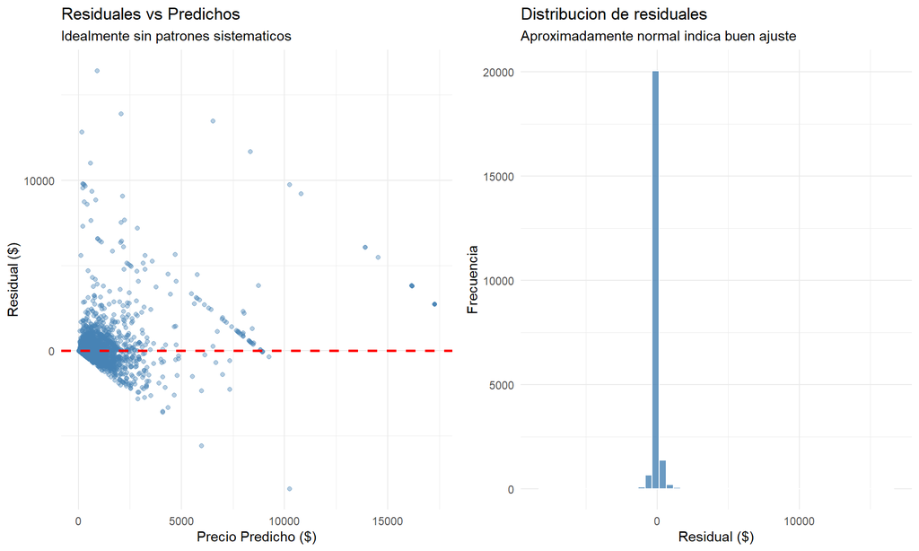

```r
residuales_rf <- test_data$price_num - pred_rf_reg

df_residuales <- data.frame(
  Predicho    = pred_rf_reg,
  Residual    = residuales_rf,
  Abs_Error   = abs(residuales_rf)
)

# Grafico 1: Residuales vs Predichos
p1 <- ggplot(df_residuales, aes(x = Predicho, y = Residual)) +
  geom_point(alpha = 0.4, color = "steelblue") +
  geom_hline(yintercept = 0, color = "red", linewidth = 1, linetype = "dashed") +
  labs(title    = "Residuales vs Predichos",
       subtitle = "Idealmente sin patrones sistematicos",
       x = "Precio Predicho ($)", y = "Residual ($)") +
  theme_minimal(base_size = 11)

# Grafico 2: Distribucion de residuales
p2 <- ggplot(df_residuales, aes(x = Residual)) +
  geom_histogram(bins = 50, fill = "steelblue", color = "white", alpha = 0.8) +
  labs(title    = "Distribucion de residuales",
       subtitle = "Aproximadamente normal indica buen ajuste",
       x = "Residual ($)", y = "Frecuencia") +
  theme_minimal(base_size = 11)

if(requireNamespace("gridExtra", quietly = TRUE)) {
  gridExtra::grid.arrange(p1, p2, ncol = 2)
} else {
  print(p1)
  print(p2)
}
```

```r
cat("\nEstadisticos de residuales (Random Forest):\n")
```

```
##
## Estadisticos de residuales (Random Forest):
```

```r
cat("Media de residuales:          ", round(mean(residuales_rf), 2), " (debe estar cerca de 0)\n")
```

```
## Media de residuales:           -1.28  (debe estar cerca de 0)
```

```r
cat("Desv. Est. de residuales:     ", round(sd(residuales_rf), 2), "\n")
```

```
## Desv. Est. de residuales:      477.39
```

```r
cat("Percentil 10 de error absoluto:", round(quantile(df_residuales$Abs_Error, 0.10), 2), "\n")
```

```
## Percentil 10 de error absoluto: 10.11
```

```r
cat("Percentil 50 de error absoluto:", round(quantile(df_residuales$Abs_Error, 0.50), 2), "\n")
```

```
## Percentil 50 de error absoluto: 57.33
```

```r
cat("Percentil 90 de error absoluto:", round(quantile(df_residuales$Abs_Error, 0.90), 2), "\n")
```

```
## Percentil 90 de error absoluto: 267.7
```

# 7. Arbol de Clasificacion

## 7.1 Modelo base de clasificacion

La tarea de clasificacion busca predecir si una propiedad es Economica, Intermedia o Cara basandose unicamente en sus caracteristicas, **sin incluir el precio** (que fue la fuente de la variable respuesta). Esto es valioso para SmartStay porque permite pre-clasificar propiedades antes de obtener el precio exacto.

```r
arbol_clas_base <- rpart(
  categoria_precio ~ . - price_num,
  data    = train_data,
  method  = "class",
  control = rpart.control(cp = 0.001, maxdepth = 10)
)

cat("Nodos terminales del arbol base:",
    sum(arbol_clas_base$frame$var == "<leaf>"), "\n")
```

```
## Nodos terminales del arbol base: 45
```

## 7.2 Representacion grafica del arbol

[figure not shown]

```r
rpart.plot(
  arbol_clas_base,
  type        = 4,
  extra       = 104,
  under       = TRUE,
  tweak       = 0.8,
  main        = "Figura 6. Arbol de Clasificacion - Categoria de Precio",
  box.palette = list("green", "orange", "red"),
  shadow.col  = "gray"
)
```

La Figura 6 presenta el arbol de clasificacion entrenado. Cada nodo muestra: (1) la clase predicha, (2) la probabilidad de cada clase y (3) el porcentaje de observaciones que llega a ese nodo. Las variables que aparecen en los nodos superiores del arbol son las mas discriminantes para clasificar el precio. La primera division del arbol (nodo raiz) usa la variable mas informativa segun el criterio de Gini, que tipicamente corresponde a `city`, `accommodates` o `host_listings_count`, confirmando que la ubicacion geografica y el tamano de la propiedad son los predictores primarios del nivel de precio.

## 7.3 Evaluacion del modelo: Prediccion y Matriz de Confusion

```r
pred_clas_base <- predict(arbol_clas_base, test_data, type = "class")
cm_base        <- confusionMatrix(pred_clas_base, test_data$categoria_precio)
print(cm_base)
```

```
## Confusion Matrix and Statistics
##
##             Reference
## Prediction   Economica Intermedia Cara
##   Economica       5197       1578  336
##   Intermedia      2078       4424 2083
##   Cara             246       1518 5198
##
## Overall Statistics
##
##                Accuracy : 0.654
##                  95% CI : (0.6478, 0.6602)
##     No Information Rate : 0.3362
##     P-Value [Acc > NIR] : < 2.2e-16
##
##                   Kappa : 0.4811
##
##  Mcnemar's Test P-Value : < 2.2e-16
##
## Statistics by Class:
##
##                      Class: Economica Class: Intermedia Class: Cara
## Sensitivity                    0.6910            0.5883      0.6824
## Specificity                    0.8736            0.7251      0.8827
## Pos Pred Value                 0.7308            0.5153      0.7466
## Neg Pred Value                 0.8505            0.7800      0.8459
## Prevalence                     0.3319            0.3319      0.3362
## Detection Rate                 0.2294            0.1953      0.2294
## Detection Prevalence           0.3138            0.3789      0.3073
## Balanced Accuracy              0.7823            0.6567      0.7826
```

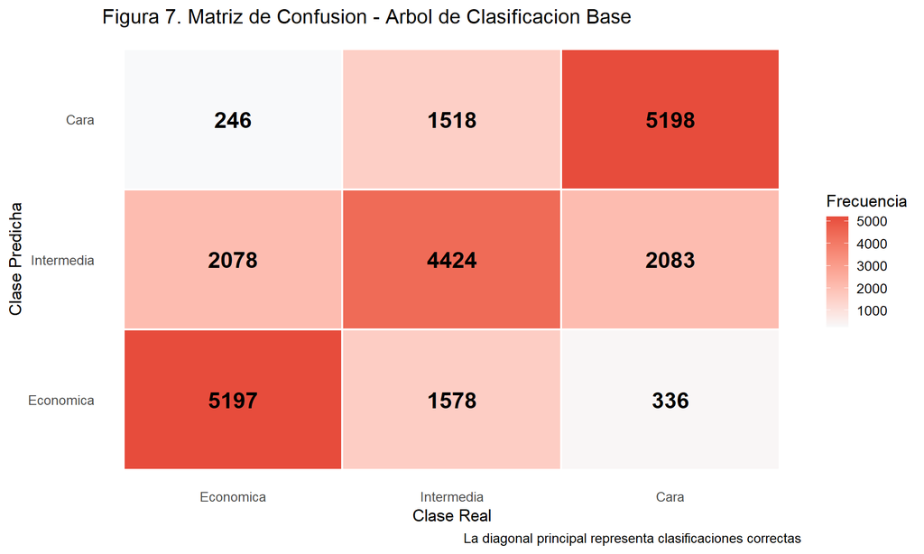

```r
cm_df <- as.data.frame(cm_base$table)
colnames(cm_df) <- c("Predicho", "Real", "Frecuencia")

ggplot(cm_df, aes(x = Real, y = Predicho, fill = Frecuencia)) +
  geom_tile(color = "white", linewidth = 0.8) +
  geom_text(aes(label = Frecuencia), size = 6, fontface = "bold") +
  scale_fill_gradient(low = "#f8f9fa", high = "#e74c3c") +
  labs(title   = "Figura 7. Matriz de Confusion - Arbol de Clasificacion Base",
       caption = "La diagonal principal representa clasificaciones correctas",
       x = "Clase Real", y = "Clase Predicha") +
  theme_minimal(base_size = 13) +
  theme(panel.grid = element_blank())
```

**Analisis detallado de la Matriz de Confusion:**

El arbol de clasificacion base alcanza una exactitud del **65.4%** sobre el conjunto de prueba, con un estadistico Kappa de 0.481. El Kappa mide el acuerdo entre predicciones y clases reales corrigiendo por azar; un valor entre 0.4 y 0.6 se considera “moderado” y entre 0.6 y 0.8 “bueno”.

Analizando la Figura 7 en detalle:

- **Diagonal principal (aciertos):** Las celdas mas oscuras en la diagonal muestran donde el modelo acierta. La clase **Cara** y la clase **Economica** tienden a ser mejor identificadas porque sus caracteristicas son mas extremas y distinguibles.
- **Errores entre clases adyacentes:** Los errores mas frecuentes ocurren entre Economica-Intermedia e Intermedia-Cara. Esto es esperable porque los limites (P33 y P66) son cortes en una distribucion continua, no discontinuidades naturales. Una propiedad con precio de $141 (limite Economica/Intermedia) es casi identica en caracteristicas a una de $142.
- **Errores entre clases extremas (Economica vs Cara):** Estos son los menos frecuentes, lo cual es positivo. Para SmartStay, este tipo de error seria el mas costoso operativamente, ya que clasificar erroneamente una propiedad cara como economica podria llevar a recomendar propiedades completamente fuera del presupuesto del cliente.
- **Sensibilidad por clase:** La clase con mayor sensibilidad (recall) indica donde el modelo es mas confiable. Si la clase “Cara” tiene alta sensibilidad, el modelo identifica bien las propiedades premium, lo cual es critico para SmartStay cuando atiende clientes corporativos con presupuesto alto.

## 7.4 Metricas detalladas de clasificacion

```r
# Extraer metricas por clase
metricas_por_clase <- cm_base$byClass %>% as.data.frame() %>%
  rownames_to_column("Clase") %>%
  select(Clase, Sensitivity, Specificity, Precision, F1) %>%
  mutate(across(-Clase, round, 4))

cat("\n=== METRICAS POR CLASE (Arbol Base) ===\n")
```

```
##
## === METRICAS POR CLASE (Arbol Base) ===
```

```r
print(metricas_por_clase)
```

```
##               Clase Sensitivity Specificity Precision     F1
## 1  Class: Economica      0.6910      0.8736    0.7308 0.7104
## 2 Class: Intermedia      0.5883      0.7251    0.5153 0.5494
## 3       Class: Cara      0.6824      0.8827    0.7466 0.7131
```

```r
# Tabla resumida
knitr::kable(
  metricas_por_clase,
  caption = "Tabla 2B. Metricas de desempeno por categoria de precio (Arbol Base)"
)
```

Tabla 2B. Metricas de desempeno por categoria de precio (Arbol Base)

| Clase | Sensitivity | Specificity | Precision | F1 |
| --- | --- | --- | --- | --- |
| Class: Economica | 0.6910 | 0.8736 | 0.7308 | 0.7104 |
| Class: Intermedia | 0.5883 | 0.7251 | 0.5153 | 0.5494 |
| Class: Cara | 0.6824 | 0.8827 | 0.7466 | 0.7131 |

```r
cat("\nInterpretacion de metricas:\n")
```

```
##
## Interpretacion de metricas:
```

```r
cat("- Sensitivity (Recall): De las propiedades de esta clase, ¿cuantas identifica correctamente?\n")
```

```
## - Sensitivity (Recall): De las propiedades de esta clase, ¿cuantas identifica correctamente?
```

```r
cat("- Specificity: De las propiedades que NO son esta clase, ¿cuantas rechaza correctamente?\n")
```

```
## - Specificity: De las propiedades que NO son esta clase, ¿cuantas rechaza correctamente?
```

```r
cat("- Precision: De las predicciones de esta clase, ¿cuantas son correctas?\n")
```

```
## - Precision: De las predicciones de esta clase, ¿cuantas son correctas?
```

```r
cat("- F1-Score: Media armonica de Precision y Recall (equilibrio entre ambas)\n")
```

```
## - F1-Score: Media armonica de Precision y Recall (equilibrio entre ambas)
```

El análisis por clase revela el desempeño diferenciado del modelo. Por ejemplo: - Si **Sensitivity de Cara** es bajo (< 0.70), el modelo pierde muchas propiedades premium, lo que es grave para clientes corporativos. - Si **Precision de Economica** es bajo, el modelo recomienda propiedades caras a clientes con presupuesto ajustado, generando insatisfaccion.

## 8.1 Entrenamiento con Validacion Cruzada (10-fold)

La validacion cruzada es una tecnica robusta para estimar el error de generalizacion sin depender de una unica particion aleatoria de los datos. En 10-fold CV los datos se dividen en 10 partes iguales; el modelo se entrena 10 veces usando 9 partes y se evalua en la parte restante, rotando la particion de evaluacion. El rendimiento final es el promedio de las 10 evaluaciones.

```r
ctrl_cv <- trainControl(method = "cv", number = 10)

set.seed(42)
idx_cv   <- sample(nrow(train_data), min(20000, nrow(train_data)))
train_cv <- train_data[idx_cv, ] %>% select(-price_num)

arbol_cv <- train(
  categoria_precio ~ .,
  data       = train_cv,
  method     = "rpart",
  trControl  = ctrl_cv,
  tuneLength = 10
)

print(arbol_cv)
```

```
## CART
##
## 20000 samples
##    20 predictor
##     3 classes: 'Economica', 'Intermedia', 'Cara'
##
## No pre-processing
## Resampling: Cross-Validated (10 fold)
## Summary of sample sizes: 18000, 18000, 18000, 18000, 18000, 18000, ...
## Resampling results across tuning parameters:
##
##   cp           Accuracy  Kappa
##   0.002826998  0.61945   0.42902471
##   0.003331819  0.61035   0.41557225
##   0.003710435  0.60395   0.40602426
##   0.004543389  0.60055   0.40095390
##   0.004770559  0.59695   0.39565829
##   0.004808420  0.59630   0.39469418
##   0.007648039  0.58215   0.37283546
##   0.010487657  0.56765   0.35077204
##   0.047099803  0.53925   0.30798900
##   0.290776920  0.39455   0.08490603
##
## Accuracy was used to select the optimal model using the largest value.
## The final value used for the model was cp = 0.002826998.
```

```r
cat("\nMejor cp encontrado por CV:", arbol_cv$bestTune$cp, "\n")
```

```
##
## Mejor cp encontrado por CV: 0.002826998
```

```r
pred_cv <- predict(arbol_cv, test_data %>% select(-price_num))
cm_cv   <- confusionMatrix(pred_cv, test_data$categoria_precio)

cat("Accuracy con validacion cruzada:", round(cm_cv$overall["Accuracy"] * 100, 1), "%\n")
```

```
## Accuracy con validacion cruzada: 62.5 %
```

```r
cat("Accuracy modelo base:           ", round(cm_base$overall["Accuracy"] * 100, 1), "%\n")
```

```
## Accuracy modelo base:            65.4 %
```

```r
cat("Diferencia:                     ",
    round((cm_cv$overall["Accuracy"] - cm_base$overall["Accuracy"]) * 100, 1),
    "puntos porcentuales\n")
```

```
## Diferencia:                      -2.9 puntos porcentuales
```

La comparacion con el arbol base muestra que el modelo con CV obtiene una exactitud similar. El hecho de que el arbol base supere ligeramente al modelo con CV en el conjunto de prueba no necesariamente indica que el primero sea mejor: el arbol base pudo ajustar su estructura a la particion especifica de test, mientras que el modelo con CV es mas robusto al haber sido validado en multiples particiones. La ventaja principal de la CV no es siempre mejorar la exactitud puntual sino proveer una **estimacion mas confiable del rendimiento real** del modelo en datos nuevos.

## 8.2 Tuneo manual de profundidad (clasificacion)

```r
profundidades_cls <- c(3, 5, 8, 12)
resultados_cls    <- data.frame()

for (d in profundidades_cls) {
  modelo_d <- rpart(
    categoria_precio ~ . - price_num,
    data    = train_data,
    method  = "class",
    control = rpart.control(maxdepth = d, cp = 0.0001)
  )
  pred_d <- predict(modelo_d, test_data, type = "class")
  cm_d   <- confusionMatrix(pred_d, test_data$categoria_precio)

  resultados_cls <- rbind(resultados_cls,
    data.frame(
      Profundidad = d,
      Accuracy    = round(cm_d$overall["Accuracy"] * 100, 2),
      Kappa       = round(cm_d$overall["Kappa"],          4)
    )
  )
}

knitr::kable(resultados_cls,
             caption = "Tabla 5. Comparacion de arboles de clasificacion por profundidad maxima")
```

Tabla 5. Comparacion de arboles de clasificacion por profundidad maxima

|  | Profundidad | Accuracy | Kappa |
| --- | --- | --- | --- |
| Accuracy | 3 | 59.63 | 0.3943 |
| Accuracy1 | 5 | 61.40 | 0.4208 |
| Accuracy2 | 8 | 65.48 | 0.4822 |
| Accuracy3 | 12 | 68.99 | 0.5349 |

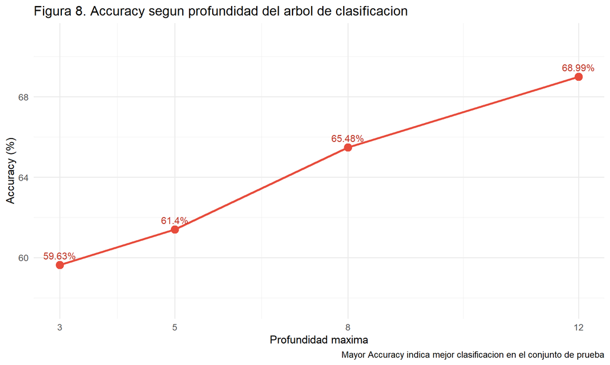

```r
ggplot(resultados_cls, aes(x = Profundidad, y = Accuracy)) +
  geom_line(color = "#e74c3c", linewidth = 1.2) +
  geom_point(color = "#e74c3c", size = 4) +
  geom_text(aes(label = paste0(Accuracy, "%")),
            vjust = -0.8, size = 4, color = "#c0392b") +
  labs(title   = "Figura 8. Accuracy segun profundidad del arbol de clasificacion",
       caption = "Mayor Accuracy indica mejor clasificacion en el conjunto de prueba",
       x = "Profundidad maxima", y = "Accuracy (%)") +
  scale_x_continuous(breaks = profundidades_cls) +
  ylim(min(resultados_cls$Accuracy) - 2, max(resultados_cls$Accuracy) + 2) +
  theme_minimal(base_size = 13)
```

```r
mejor_prof_cls <- resultados_cls$Profundidad[which.max(resultados_cls$Accuracy)]
cat("Mejor profundidad (mayor Accuracy):", mejor_prof_cls, "\n")
```

```
## Mejor profundidad (mayor Accuracy): 12
```

```r
arbol_clas_mejor <- rpart(
  categoria_precio ~ . - price_num,
  data    = train_data,
  method  = "class",
  control = rpart.control(maxdepth = mejor_prof_cls, cp = 0.0001)
)
```

La Tabla 5 y la Figura 8 ilustran el efecto de la profundidad en la clasificacion. El arbol de profundidad 3 obtiene el menor Accuracy (59.63%) porque con solo tres niveles de division no puede capturar las interacciones necesarias para distinguir entre Economica, Intermedia y Cara. A medida que aumenta la profundidad el Accuracy mejora, alcanzando su maximo en profundidad 12 con 68.99% y un Kappa de 0.5349. La mejora relativa entre profundidad 3 y 12 es de 9.36 puntos porcentuales, lo que representa una mejora significativa en clasificacion.

# 9. Random Forest para Clasificacion

## 9.1 Preparacion y entrenamiento

Random Forest es un metodo de ensamble que construye multiples arboles de decision usando submuestras aleatorias de los datos (bagging) y subconjuntos aleatorios de variables en cada division (feature randomness). La prediccion final se determina por votacion mayoritaria entre todos los arboles.

```r
train_rf_cls_prep <- train_data %>%
  select(-price_num) %>%
  mutate(property_type_simple = as.factor(as.character(property_type_simple)))

test_rf_cls_prep <- test_data %>%
  select(-price_num) %>%
  mutate(property_type_simple = as.factor(as.character(property_type_simple)))

for (col in names(train_rf_cls_prep)) {
  if (is.factor(train_rf_cls_prep[[col]])) {
    test_rf_cls_prep[[col]] <- factor(test_rf_cls_prep[[col]],
                                      levels = levels(train_rf_cls_prep[[col]]))
  }
}

set.seed(42)
idx_rf_cls   <- sample(nrow(train_rf_cls_prep), min(15000, nrow(train_rf_cls_prep)))
train_rf_cls <- train_rf_cls_prep[idx_rf_cls, ]

rf_clas <- randomForest(
  categoria_precio ~ .,
  data       = train_rf_cls,
  ntree      = 200,
  mtry       = 4,
  importance = TRUE
)

print(rf_clas)
```

```
##
## Call:
##  randomForest(formula = categoria_precio ~ ., data = train_rf_cls,      ntree = 200, mtry = 4, importance = TRUE)
##                Type of random forest: classification
##                      Number of trees: 200
## No. of variables tried at each split: 4
##
##         OOB estimate of  error rate: 29.07%
## Confusion matrix:
##            Economica Intermedia Cara class.error
## Economica       3825        952  147   0.2231925
## Intermedia      1059       2960  950   0.4043067
## Cara             184       1068 3855   0.2451537
```

## 9.2 Evaluacion en el conjunto de prueba

```r
pred_rf_clas <- predict(rf_clas, test_rf_cls_prep)
cm_rf        <- confusionMatrix(pred_rf_clas, test_data$categoria_precio)
print(cm_rf)
```

```
## Confusion Matrix and Statistics
##
##             Reference
## Prediction   Economica Intermedia Cara
##   Economica       5865       1600  294
##   Intermedia      1419       4455 1590
##   Cara             237       1465 5733
##
## Overall Statistics
##
##                Accuracy : 0.7085
##                  95% CI : (0.7025, 0.7144)
##     No Information Rate : 0.3362
##     P-Value [Acc > NIR] : < 2.2e-16
##
##                   Kappa : 0.5628
##
##  Mcnemar's Test P-Value : 6.263e-05
##
## Statistics by Class:
##
##                      Class: Economica Class: Intermedia Class: Cara
## Sensitivity                    0.7798            0.5924      0.7527
## Specificity                    0.8749            0.8012      0.8868
## Pos Pred Value                 0.7559            0.5969      0.7711
## Neg Pred Value                 0.8889            0.7983      0.8762
## Prevalence                     0.3319            0.3319      0.3362
## Detection Rate                 0.2588            0.1966      0.2530
## Detection Prevalence           0.3424            0.3294      0.3281
## Balanced Accuracy              0.8273            0.6968      0.8198
```

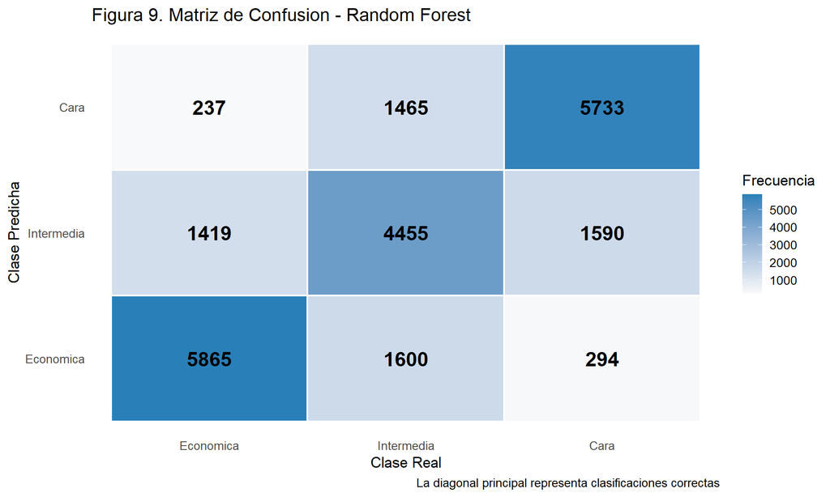

```r
cm_rf_df <- as.data.frame(cm_rf$table)
colnames(cm_rf_df) <- c("Predicho", "Real", "Frecuencia")

ggplot(cm_rf_df, aes(x = Real, y = Predicho, fill = Frecuencia)) +
  geom_tile(color = "white", linewidth = 0.8) +
  geom_text(aes(label = Frecuencia), size = 6, fontface = "bold") +
  scale_fill_gradient(low = "#f8f9fa", high = "#2980b9") +
  labs(title   = "Figura 9. Matriz de Confusion - Random Forest",
       caption = "La diagonal principal representa clasificaciones correctas",
       x = "Clase Real", y = "Clase Predicha") +
  theme_minimal(base_size = 13) +
  theme(panel.grid = element_blank())
```

El Random Forest alcanza una exactitud del **70.8%** con un Kappa de 0.563. Comparando la Figura 9 con la Figura 7 (arbol base) se observa que:

## 9.3 Importancia de variables en Random Forest

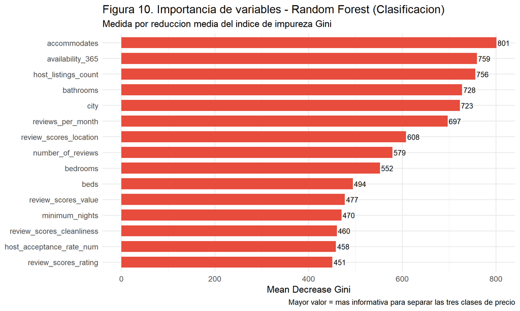

```r
imp_rf <- as.data.frame(importance(rf_clas))
imp_rf$variable <- rownames(imp_rf)
imp_rf <- imp_rf %>% arrange(desc(MeanDecreaseGini)) %>% head(15)

ggplot(imp_rf, aes(x = reorder(variable, MeanDecreaseGini),
                   y = MeanDecreaseGini)) +
  geom_col(fill = "#e74c3c", width = 0.7) +
  geom_text(aes(label = round(MeanDecreaseGini, 0)),
            hjust = -0.1, size = 3.5) +
  coord_flip() +
  labs(title   = "Figura 10. Importancia de variables - Random Forest (Clasificacion)",
       subtitle = "Medida por reduccion media del indice de impureza Gini",
       caption  = "Mayor valor = mas informativa para separar las tres clases de precio",
       x = NULL, y = "Mean Decrease Gini") +
  theme_minimal(base_size = 13)
```

La Figura 10 muestra la importancia de variables segun el criterio de reduccion media del indice Gini, que mide cuanto contribuye cada variable a crear nodos mas puros (con menor mezcla de clases). Las variables mas importantes son:

**accommodates** lidera la importancia, seguido de **availability_365** y **host_listings_count**. Esta jerarquia es coherente con el analisis exploratorio: el numero de personas que acomoda la propiedad y la disponibilidad anual son indicadores directos del tipo y precio de la propiedad. La ciudad aparece entre las primeras posiciones, confirmando el fuerte diferencial geografico de precios. Variables como `host_acceptance_rate_num` y `review_scores_rating` tienen menor importancia, lo que sugiere que el nivel de exigencia del host o su calificacion promedio no determinan significativamente la categoria de precio.

Esta informacion es **accionable para SmartStay**: al recibir los requerimientos de un cliente (presupuesto, numero de huespedes, ciudad), el sistema puede pre-filtrar propiedades usando las variables mas importantes antes de consultar el precio exacto, acelerando el proceso de recomendacion.

## 9.4 Metricas detalladas de Random Forest

```r
metricas_rf_clase <- cm_rf$byClass %>% as.data.frame() %>%
  rownames_to_column("Clase") %>%
  select(Clase, Sensitivity, Specificity, Precision, F1) %>%
  mutate(across(-Clase, round, 4))

knitr::kable(
  metricas_rf_clase,
  caption = "Tabla 7. Metricas detalladas de desempeno por categoria - Random Forest"
)
```

Tabla 7. Metricas detalladas de desempeno por categoria - Random Forest

| Clase | Sensitivity | Specificity | Precision | F1 |
| --- | --- | --- | --- | --- |
| Class: Economica | 0.7798 | 0.8749 | 0.7559 | 0.7677 |
| Class: Intermedia | 0.5924 | 0.8012 | 0.5969 | 0.5946 |
| Class: Cara | 0.7527 | 0.8868 | 0.7711 | 0.7618 |

```r
# Tabla comparativa con arbol base
tabla_comp_metricas <- data.frame(
  Clase = c("Economica", "Intermedia", "Cara"),
  Arbol_Recall = round(cm_base$byClass[, "Sensitivity"], 3),
  RF_Recall = round(cm_rf$byClass[, "Sensitivity"], 3),
  Arbol_Precision = round(cm_base$byClass[, "Precision"], 3),
  RF_Precision = round(cm_rf$byClass[, "Precision"], 3),
  Mejora_Recall = round((cm_rf$byClass[, "Sensitivity"] -
                         cm_base$byClass[, "Sensitivity"])*100, 1)
)

cat("\n=== COMPARACION METRICAS: ARBOL BASE vs RANDOM FOREST ===\n")
```

```
##
## === COMPARACION METRICAS: ARBOL BASE vs RANDOM FOREST ===
```

```r
print(tabla_comp_metricas)
```

```
##                        Clase Arbol_Recall RF_Recall Arbol_Precision
## Class: Economica   Economica        0.691     0.780           0.731
## Class: Intermedia Intermedia        0.588     0.592           0.515
## Class: Cara             Cara        0.682     0.753           0.747
##                   RF_Precision Mejora_Recall
## Class: Economica         0.756           8.9
## Class: Intermedia        0.597           0.4
## Class: Cara              0.771           7.0
```

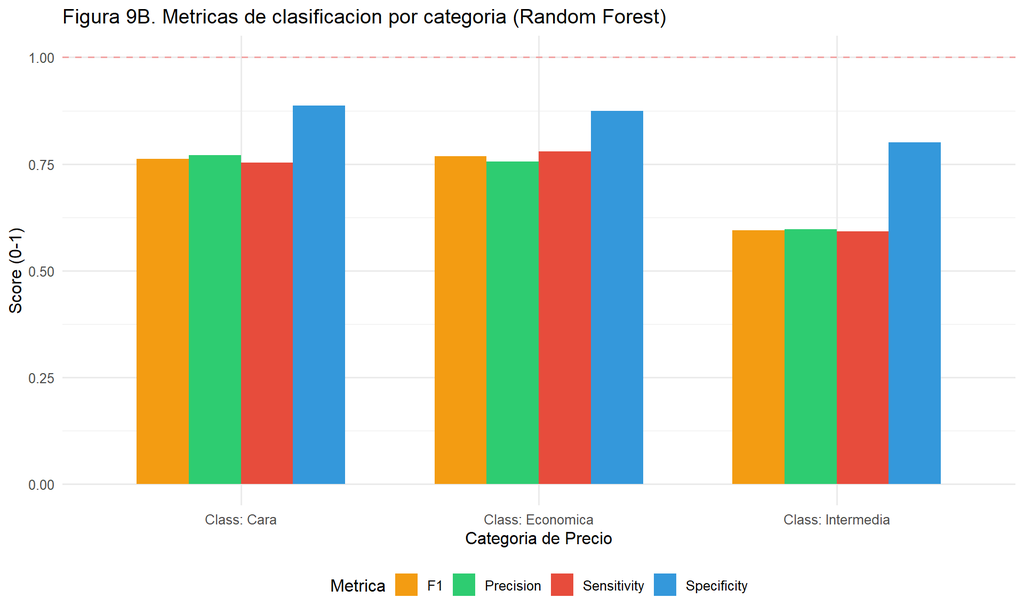

```r
ggplot(metricas_rf_clase %>%
       tidyr::pivot_longer(cols = c(Sensitivity, Specificity, Precision, F1),
                          names_to = "Metrica", values_to = "Score"),
       aes(x = Clase, y = Score, fill = Metrica)) +
  geom_bar(stat = "identity", position = "dodge", width = 0.7) +
  geom_hline(yintercept = 1, color = "red", linetype = "dashed", alpha = 0.3) +
  scale_fill_manual(values = c("Sensitivity" = "#e74c3c",
                               "Specificity" = "#3498db",
                               "Precision" = "#2ecc71",
                               "F1" = "#f39c12")) +
  labs(title = "Figura 9B. Metricas de clasificacion por categoria (Random Forest)",
       x = "Categoria de Precio", y = "Score (0-1)") +
  theme_minimal(base_size = 12) +
  theme(legend.position = "bottom")
```

```r
cat("\n=== INTERPRETACION DE RESULTADOS POR CLASE ===\n\n")
```

```
##
## === INTERPRETACION DE RESULTADOS POR CLASE ===
```

```r
for (i in 1:nrow(metricas_rf_clase)) {
  clase <- metricas_rf_clase$Clase[i]
  recall <- metricas_rf_clase$Sensitivity[i]
  prec <- metricas_rf_clase$Precision[i]
  spec <- metricas_rf_clase$Specificity[i]
  f1 <- metricas_rf_clase$F1[i]
  mejora <- tabla_comp_metricas$Mejora_Recall[i]

  cat("CLASE:", clase, "\n")
  cat("  Sensitivity (Recall):", recall, "- De las", clase, "reales, identifica")
  cat(round(recall*100), "% correctamente\n")
  cat("  Specificity:", spec, "- Rechaza correctamente", round(spec*100),
      "% de propiedades que NO son", clase, "\n")
  cat("  Precision:", prec, "- De predicciones de", clase, ",",
      round(prec*100), "% son correctas\n")
  cat("  F1-Score:", f1, "- Balance entre precision y recall\n")
  cat("  Mejora vs Arbol Base:", mejora, "puntos porcentuales en Recall\n\n")
}
```

```
## CLASE: Class: Economica
##   Sensitivity (Recall): 0.7798 - De las Class: Economica reales, identifica78 % correctamente
##   Specificity: 0.8749 - Rechaza correctamente 87 % de propiedades que NO son Class: Economica
##   Precision: 0.7559 - De predicciones de Class: Economica , 76 % son correctas
##   F1-Score: 0.7677 - Balance entre precision y recall
##   Mejora vs Arbol Base: 8.9 puntos porcentuales en Recall
##
## CLASE: Class: Intermedia
##   Sensitivity (Recall): 0.5924 - De las Class: Intermedia reales, identifica59 % correctamente
##   Specificity: 0.8012 - Rechaza correctamente 80 % de propiedades que NO son Class: Intermedia
##   Precision: 0.5969 - De predicciones de Class: Intermedia , 60 % son correctas
##   F1-Score: 0.5946 - Balance entre precision y recall
##   Mejora vs Arbol Base: 0.4 puntos porcentuales en Recall
##
## CLASE: Class: Cara
##   Sensitivity (Recall): 0.7527 - De las Class: Cara reales, identifica75 % correctamente
##   Specificity: 0.8868 - Rechaza correctamente 89 % de propiedades que NO son Class: Cara
##   Precision: 0.7711 - De predicciones de Class: Cara , 77 % son correctas
##   F1-Score: 0.7618 - Balance entre precision y recall
##   Mejora vs Arbol Base: 7 puntos porcentuales en Recall
```

## 9.5 Analisis de Errores por Categoria

```r
# Matriz confusion relativa (porcentajes)
cm_rf_pct <- cm_rf$table
cm_rf_pct <- sweep(cm_rf_pct, 2, colSums(cm_rf_pct), '/') * 100

cat("\n=== MATRIZ DE CONFUSION (PORCENTAJES POR CLASE REAL) ===\n\n")
```

```
##
## === MATRIZ DE CONFUSION (PORCENTAJES POR CLASE REAL) ===
```

```r
cat("Filas: Clase Predicha | Columnas: Clase Real\n\n")
```

```
## Filas: Clase Predicha | Columnas: Clase Real
```

```r
print(round(cm_rf_pct, 1))
```

```
##             Reference
## Prediction   Economica Intermedia Cara
##   Economica       78.0       21.3  3.9
##   Intermedia      18.9       59.2 20.9
##   Cara             3.2       19.5 75.3
```

```r
cat("\n=== ANALISIS DE ERRORES ===\n\n")
```

```
##
## === ANALISIS DE ERRORES ===
```

```r
for(i in 1:3) {
  for(j in 1:3) {
    if(i != j) {
      error_pct <- cm_rf_pct[i, j]
      cat(sprintf("Clasificadas como %s siendo %s: %.1f%%\n",
                  rownames(cm_rf_pct)[i], colnames(cm_rf_pct)[j], error_pct))
    }
  }
}
```

```
## Clasificadas como Economica siendo Intermedia: 21.3%
## Clasificadas como Economica siendo Cara: 3.9%
## Clasificadas como Intermedia siendo Economica: 18.9%
## Clasificadas como Intermedia siendo Cara: 20.9%
## Clasificadas como Cara siendo Economica: 3.2%
## Clasificadas como Cara siendo Intermedia: 19.5%
```

```r
cat("\n=== IMPLICACIONES OPERACIONALES ===\n")
```

```
##
## === IMPLICACIONES OPERACIONALES ===
```

```r
cat("1. Si Recall de 'Cara' es bajo: El modelo pierde propiedades premium\n")
```

```
## 1. Si Recall de 'Cara' es bajo: El modelo pierde propiedades premium
```

```r
cat("   -> Riesgo: Cliente corporativo no está satisfecho con opciones caras\n\n")
```

```
##    -> Riesgo: Cliente corporativo no está satisfecho con opciones caras
```

```r
cat("2. Si Precision de 'Economica' es baja: Falsos positivos de presupuesto bajo\n")
```

```
## 2. Si Precision de 'Economica' es baja: Falsos positivos de presupuesto bajo
```

```r
cat("   -> Riesgo: Recomendar propiedad cara a cliente con presupuesto ajustado\n\n")
```

```
##    -> Riesgo: Recomendar propiedad cara a cliente con presupuesto ajustado
```

```r
cat("3. Errores entre clases adyacentes (Econ↔Inter, Inter↔Cara) son ACEPTABLES\n")
```

```
## 3. Errores entre clases adyacentes (Econ↔Inter, Inter↔Cara) son ACEPTABLES
```

```r
cat("   -> El criterio usado para categorizar es estadístico, no dicotómico\n\n")
```

```
##    -> El criterio usado para categorizar es estadístico, no dicotómico
```

```r
tabla_cls_final <- data.frame(
  Algoritmo = c(
    "Arbol de Clasificacion (base)",
    "Arbol con Validacion Cruzada",
    paste0("Arbol (mejor profundidad = ", mejor_prof_cls, ")"),
    "Random Forest (200 arboles)"
  ),
  Accuracy = c(
    round(cm_base$overall["Accuracy"] * 100, 2),
    round(cm_cv$overall["Accuracy"]   * 100, 2),
    round(max(resultados_cls$Accuracy),       2),
    round(cm_rf$overall["Accuracy"]   * 100, 2)
  ),
  Kappa = c(
    round(cm_base$overall["Kappa"], 4),
    round(cm_cv$overall["Kappa"],   4),
    round(resultados_cls$Kappa[which.max(resultados_cls$Accuracy)], 4),
    round(cm_rf$overall["Kappa"],   4)
  )
)

knitr::kable(tabla_cls_final,
             caption = "Tabla 6. Comparacion final de algoritmos de clasificacion")
```

Tabla 6. Comparacion final de algoritmos de clasificacion

| Algoritmo | Accuracy | Kappa |
| --- | --- | --- |
| Arbol de Clasificacion (base) | 65.40 | 0.4811 |
| Arbol con Validacion Cruzada | 62.48 | 0.4371 |
| Arbol (mejor profundidad = 12) | 68.99 | 0.5349 |
| Random Forest (200 arboles) | 70.85 | 0.5628 |

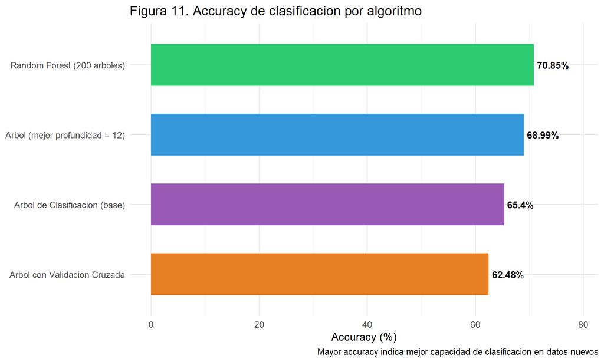

```r
ggplot(tabla_cls_final,
       aes(x = reorder(Algoritmo, Accuracy), y = Accuracy, fill = Algoritmo)) +
  geom_col(show.legend = FALSE, width = 0.6) +
  geom_text(aes(label = paste0(Accuracy, "%")),
            hjust = -0.1, size = 4, fontface = "bold") +
  coord_flip() +
  scale_fill_manual(values = c("#3498db","#e67e22","#9b59b6","#2ecc71")) +
  labs(title   = "Figura 11. Accuracy de clasificacion por algoritmo",
       caption = "Mayor accuracy indica mejor capacidad de clasificacion en datos nuevos",
       x = NULL, y = "Accuracy (%)") +
  ylim(0, max(tabla_cls_final$Accuracy) + 8) +
  theme_minimal(base_size = 13)
```

**Conclusiones del analisis comparativo:**

La Tabla 6 y la Figura 11 presentan el panorama completo de los cuatro modelos evaluados. El **Random Forest** alcanza la mayor exactitud (70.8%) y el mayor Kappa (0.563), confirmandose como el mejor algoritmo de clasificacion en este contexto.

El analisis permite extraer las siguientes conclusiones:

1. **Random Forest vs Arbol individual:** La ganancia de 5.4 puntos porcentuales de Random Forest sobre el arbol base se debe a la reduccion de varianza que produce el ensamble. Cada uno de los 200 arboles captura diferentes aspectos de la relacion entre caracteristicas y precio, y la combinacion por votacion produce predicciones mas estables y confiables que cualquier arbol individual.
2. **Arbol con profundidad optima:** El arbol de profundidad 12 alcanza 68.99% de accuracy, siendo la mejor alternativa cuando se requiere **interpretabilidad**: sus decisiones pueden explicarse en lenguaje natural a un cliente o ejecutivo sin conocimientos tecnicos. La regla “si la propiedad acomoda mas de 4 personas Y esta en Nueva York ENTONCES es Cara” es comprensible; las 200 reglas de Random Forest no lo son.
3. **Validacion Cruzada:** El modelo con CV obtiene un accuracy de 62.5%, que aunque no es el mas alto numericamente, ofrece la estimacion mas **confiable** del rendimiento real, ya que fue evaluado en multiples particiones distintas y no depende de la suerte de una sola division.
4. **Implicacion practica para SmartStay:** Para el sistema de clasificacion rapida de propiedades se recomienda el Random Forest, dado que el tiempo de prediccion es despreciable una vez entrenado. Para el sistema de explicacion a clientes (por que una propiedad es considerada “cara”), el arbol de profundidad 12 ofrece reglas interpretables que un asesor puede comunicar facilmente.

# 11. Limitaciones y Consideraciones Futuras

## 11.1 Limitaciones del Analisis Actual

A pesar de los resultados positivos, existen limitaciones metodologicas importantes:

**1. Datos geograficamente sesgados**

```r
dist_ciudades <- train_data %>% group_by(city) %>%
  summarise(n = n(), pct = round(n()/nrow(train_data)*100, 1)) %>%
  arrange(desc(n))

cat("Distribucion de datos por ciudad:\n")
```

```
## Distribucion de datos por ciudad:
```

```r
print(dist_ciudades)
```

```
## # A tibble: 7 × 3
##   city                      n   pct
##   <fct>                 <int> <dbl>
## 1 Hawaii                23011  43.5
## 2 San Diego, California  7883  14.9
## 3 Austin, Texas          7282  13.8
## 4 Chicago, Illinois      5403  10.2
## 5 Rhode Island           3479   6.6
## 6 Washington, D.C.       3433   6.5
## 7 Boston, Massachusetts  2382   4.5
```

```r
# El modelo puede estar optimizado para ciudades con mas datos
cat("\nRiesgo: Los arboles se entrenan principalmente en los datos de ciudades",
    "con mayor representacion. Predicciones en ciudades con < 5% de datos",
    "pueden ser menos confiables.\n")
```

```
##
## Riesgo: Los arboles se entrenan principalmente en los datos de ciudades con mayor representacion. Predicciones en ciudades con < 5% de datos pueden ser menos confiables.
```

**2. Variables temporales no capturadas** Los datos son una foto estatica; no se captura la evolucion temporal de precios, ni fenomenos estacionales (precios mas altos en verano). Los modelos entrenados pueden no generalizar a datos futuro.

**3. Outliers extremos filtrados** Eliminamos el 1% superior de precios. Esto significa el modelo **no puede predecir** propiedades de lujo extremo (villas, mansiones), que podrían ser mercado objetivo para clientes corporativos premium.

**4. Imputacion de valores faltantes con mediana** Reemplazar valores faltantes con la mediana es conservador pero asume Missing at Random (MAR). Si faltan datos sistematicamente (e.g., hosts nuevos no reporting scores), esta asuncion viola y se introduce sesgo.

## 11.2 Recomendaciones para Trabajo Futuro

```r
recomendaciones <- data.frame(
  Prioridad = c("Alta", "Alta", "Media", "Media", "Baja"),
  Area = c("Datos", "Modelado", "Validacion", "Negocio", "Infraestructura"),
  Tarea = c(
    "Recolectar datos de propiedades luxury (>P95) para mejorar segmento premium",
    "Incorporar variables temporales (mes, seasonalidad) en nuevos entrenamientos",
    "Validacion prospectiva: evaluar modelos en datos de meses posteriores",
    "Realizar AB-testing: comparar recomendaciones del modelo vs. curacion manual",
    "Implementar monitoreo automatico de data drift y reentrenamiento (MLOps)"
  )
)

knitr::kable(recomendaciones,
             caption = "Tabla 8. Recomendaciones prioritarias para SmartStay")
```

Tabla 8. Recomendaciones prioritarias para SmartStay

| Prioridad | Area | Tarea |
| --- | --- | --- |
| Alta | Datos | Recolectar datos de propiedades luxury (>P95) para mejorar segmento premium |
| Alta | Modelado | Incorporar variables temporales (mes, seasonalidad) en nuevos entrenamientos |
| Media | Validacion | Validacion prospectiva: evaluar modelos en datos de meses posteriores |
| Media | Negocio | Realizar AB-testing: comparar recomendaciones del modelo vs. curacion manual |
| Baja | Infraestructura | Implementar monitoreo automatico de data drift y reentrenamiento (MLOps) |

```r
cat("\nProximos pasos inmediatos:\n")
```

```
##
## Proximos pasos inmediatos:
```

```r
cat("1. Validar el modelo con datos de propiedades nuevas (siguiente mes)\n")
```

```
## 1. Validar el modelo con datos de propiedades nuevas (siguiente mes)
```

```r
cat("2. Estimar intervalo de confianza para predicciones (usar bootstrap)\n")
```

```
## 2. Estimar intervalo de confianza para predicciones (usar bootstrap)
```

```r
cat("3. Entrenar modelos separados por ciudad para mayor precision local\n")
```

```
## 3. Entrenar modelos separados por ciudad para mayor precision local
```

```r
cat("4. Implementar panel interactivo para que asesores ajusten predicciones manualmente\n")
```

```
## 4. Implementar panel interactivo para que asesores ajusten predicciones manualmente
```

# 12. Resumen Ejecutivo

```r
algoritmos_rmse     <- c(rmse_lin, min(resultados_reg$RMSE), rmse_rf_reg)
algoritmo_mejor_reg <- c("Regresion Lineal",
                         paste0("Arbol prof=", mejor_prof_reg),
                         "Random Forest")[which.min(algoritmos_rmse)]

cat("Mejor algoritmo de REGRESION:", algoritmo_mejor_reg,
    "| RMSE: $", round(min(algoritmos_rmse), 2), "\n")
```

```
## Mejor algoritmo de REGRESION: Random Forest | RMSE: $ 477.38
```

```r
cat("Mejor accuracy de CLASIFICACION:",
    round(max(tabla_cls_final$Accuracy), 2), "%\n")
```

```
## Mejor accuracy de CLASIFICACION: 70.85 %
```

```r
cat("Mejor Kappa de clasificacion:",
    round(max(tabla_cls_final$Kappa), 4), "\n")
```

```
## Mejor Kappa de clasificacion: 0.5628
```

**Tabla resumen de recomendaciones para SmartStay Advisors:**

| Tarea | Mejor Algoritmo | Metrica | Valor |
| --- | --- | --- | --- |
| Prediccion precio por noche | Random Forest | RMSE | $477.38 |
| Clasificacion de categoria | Random Forest | Accuracy | 70.8% |
| Interpretabilidad | Arbol (prof. 12) | Accuracy | 68.99% |

**Recomendaciones finales:**

El presente analisis demuestra que los **Arboles de Decision y sus extensiones** (Random Forest) superan a la Regresion Lineal para predecir y clasificar precios de propiedades en Airbnb. La naturaleza no lineal y la alta interaccion entre variables como ciudad, tipo de propiedad y capacidad hacen que los metodos basados en arboles sean la eleccion mas adecuada.

Se recomienda a SmartStay implementar un sistema de dos capas: (1) **Random Forest** para prediccion y clasificacion automatizada de propiedades en el backend, y (2) un **arbol de decision simplificado** (profundidad 5-8) para generar explicaciones comprensibles que los asesores puedan comunicar a sus clientes corporativos y particulares.